# Assignment 3 Key

Data Science for Biomedical Informatics (BMIN503/EPID600)

#### Cleaning and Transforming data, Descriptive Statistics and Regression

4. Install and load the `nycflights13` package to do this problem. This package includes the flights dataset, which contains information on 336,776 flights that departed from New York City in 2013 and is often used to learn `dplyr` commands. If you need more guided practice with `dplyr`, beyond what we did in class, you can go through this [vignette](https://cran.r-project.org/web/packages/dplyr/vignettes/dplyr.html). Use `dplyr` to answer the following questions by inserting code below each bullet to provide the answer directly. *(10 points)*
   - How many carriers departed NYC in 2013? Which carrier had the most departing flights?

   ```r
   library(tidyverse)
   library(nycflights13)
   flights %>%
       group_by(carrier) %>%
       summarise(n()) %>%
       arrange(desc(`n()`))
   ```

   ```
   ## # A tibble: 16 x 2
   ##    carrier `n()`
   ##    <chr>   <int>
   ##  1 UA      58665
   ##  2 B6      54635
   ##  3 EV      54173
   ##  4 DL      48110
   ##  5 AA      32729
   ##  6 MQ      26397
   ##  7 US      20536
   ##  8 9E      18460
   ##  9 WN      12275
   ## 10 VX       5162
   ## 11 FL       3260
   ## 12 AS        714
   ## 13 F9        685
   ## 14 YV        601
   ## 15 HA        342
   ## 16 OO         32
   ```

   16 carriers, UA had the most departing flights
   - Of the flights that departed in June and July, how many unique tailnum contained the letter M or P?

   ```r
   flights %>%
       filter(month %in% c(6,7)) %>%
       slice(grep("M|P", tailnum)) %>%
       summarise(tailnum = n_distinct(tailnum))
   ```

   ```
   ## # A tibble: 1 x 1
   ##   tailnum
   ##     <int>
   ## 1     261
   ```

   261
   - What was the most popular destination each month?

   ```r
   flights %>%
       group_by(month, dest) %>%
       summarise(n()) %>%
       filter(`n()` == max(`n()`))
   ```

   ```
   ## # A tibble: 12 x 3
   ## # Groups:   month [12]
   ##    month dest  `n()`
   ##    <int> <chr> <int>
   ##  1     1 ATL    1396
   ##  2     2 ATL    1267
   ##  3     3 ATL    1448
   ##  4     4 ATL    1490
   ##  5     5 ORD    1582
   ##  6     6 ORD    1547
   ##  7     7 ORD    1573
   ##  8     8 ORD    1604
   ##  9     9 ORD    1582
   ## 10    10 ORD    1604
   ## 11    11 ATL    1384
   ## 12    12 ATL    1463
   ```

   Atlanta in Jan-April and Nov-Dec; Chicago O’Hare in May-Oct
   - Was the mean departure delay time per carrier related to the total number of flights per carrier? The answer should show a plot and use one sentence to address this question qualitatively.

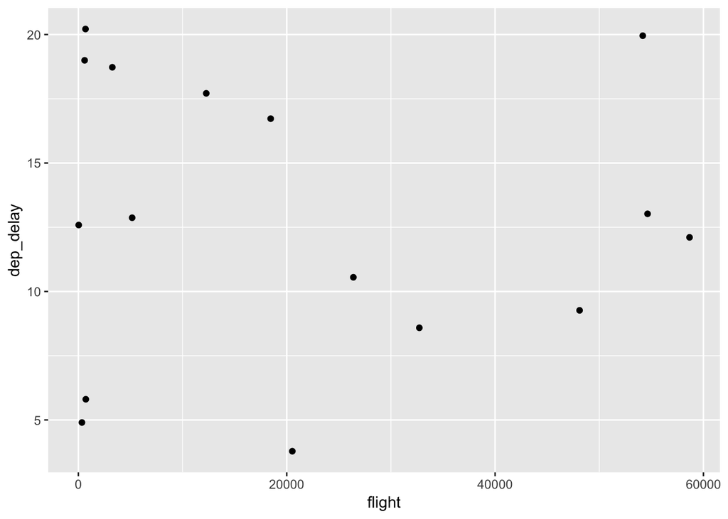

   ```r
   flights %>%
       group_by(carrier) %>%
       summarise(dep_delay = mean(dep_delay, na.rm=TRUE), flight=n()) %>%
       ggplot(., aes(x=flight, y=dep_delay)) + geom_point()
   ```

   No, there does not appear to be a pattern between mean delay time and total number of flights for a given carrier.
   - Was the mean delay time for a given time of departure related to the time of departure? The answer should show a plot and use one sentence to address this question qualitatively.

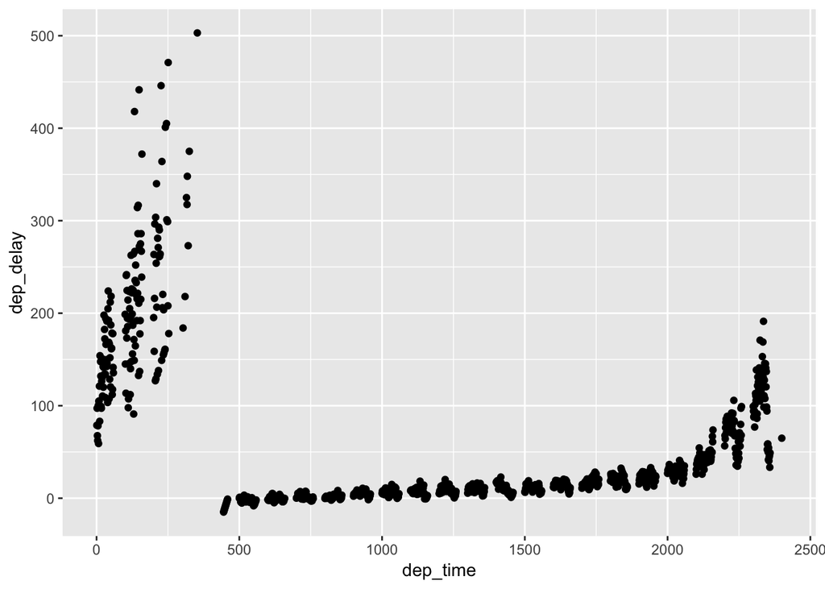

   ```r
   flights %>%
       group_by(dep_time) %>%
       summarise(dep_delay = mean(dep_delay, na.rm=TRUE)) %>%
       ggplot(., aes(x=dep_time, y=dep_delay)) + geom_point()
   ```

   Yes, there is a pattern between mean delay time and time of departure, with flights departing between 0hr and ~400hr and after ~2100hr having greatest delays.
5. Load the `MASS` package, which contains the [birthwt](https://stat.ethz.ch/R-manual/R-devel/library/MASS/html/birthwt.html) dataset, to answer the following questions. We will work toward identifying variables that are associated with low birthweight, both as a dichotomous outcome and a continuous one. HINT: The `MASS` package contains a `select` command that may compete with that from `dplyr`. If you have `dplyr` and `MASS` loaded simultaneously and want to use `dplyr`’s `select`, do it explicitly. For example, use `dplyr::select` rather than `select`. *(9 points)*
   - Take a look at the `birthwt` dataset (e.g., using `str()`) to get a sense of variables it contains. We will use the variables `low` and `bwt` as outcomes and `age`, `race`, `smoke`, `ht`, `ptl` as predictors. Create a new dataset `birthwt.clean` containing only the variables we are interested in, where (1) the variables `low`, `ht`, and `ptl` are renamed `low.birth.wt`, `hypertension`, and `prem.labor`, respectively, (2) all integer categories (i.e., `low.birth.wt`, `race`, `smoke`, `hypertension`, `prem.labor`) are converted to factors with intuitive labels, (3) keep only subjects for whom the `race` variable does not include the `other` category, and (4) the `ptl` variable is dichotomized into two levels based on a positive or negative history of previous premature labor.

   ```r
   library(MASS)
   str(birthwt)
   ```

   ```
   ## 'data.frame':    189 obs. of  10 variables:
   ##  $ low  : int  0 0 0 0 0 0 0 0 0 0 ...
   ##  $ age  : int  19 33 20 21 18 21 22 17 29 26 ...
   ##  $ lwt  : int  182 155 105 108 107 124 118 103 123 113 ...
   ##  $ race : int  2 3 1 1 1 3 1 3 1 1 ...
   ##  $ smoke: int  0 0 1 1 1 0 0 0 1 1 ...
   ##  $ ptl  : int  0 0 0 0 0 0 0 0 0 0 ...
   ##  $ ht   : int  0 0 0 0 0 0 0 0 0 0 ...
   ##  $ ui   : int  1 0 0 1 1 0 0 0 0 0 ...
   ##  $ ftv  : int  0 3 1 2 0 0 1 1 1 0 ...
   ##  $ bwt  : int  2523 2551 2557 2594 2600 2622 2637 2637 2663 2665 ...
   ```

   ```r
   birthwt.clean <- birthwt %>%
       dplyr::select(low, bwt, age, race, smoke, ht, ptl) %>%
       rename(low.birth.wt=low, hypertension=ht, prem.labor=ptl) %>%
       filter(race < 3) %>%
       mutate(low.birth.wt = factor(low.birth.wt, levels=c(0,1), labels=c("normal-wt", "low-wt"))) %>%
       mutate(race = factor(race, levels=c(1,2), labels=c("white", "black"))) %>%
       mutate(smoke = factor(smoke, levels=c(0,1), labels=c("non-smoker", "smoker"))) %>%
       mutate(hypertension = factor(hypertension, levels=c(0,1), labels=c("no-HTN", "HTN"))) %>%
       mutate(prem.labor = factor(prem.labor > 0, labels=c("no-prem-labor-hx", "prem-labor-hx")))
   ```

   - Perform bivariate analysis for the resulting `age` and `smoke` variables you created as predictors and `low.birth.wt` and `bwt` as outcomes. Include appropriate plots that look at the pairwise relationships between the outcomes and each predictor. Are there differences between the results for each outcome?

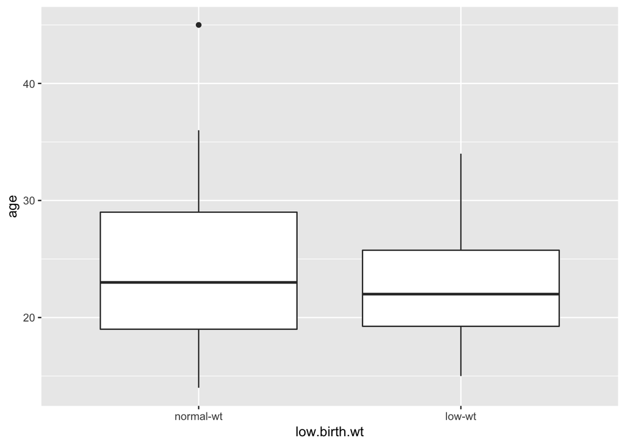

   ```r
   #For cateogrical outcome
   ggplot(birthwt.clean, aes(x=low.birth.wt, y=age)) +
       geom_boxplot()
   ```

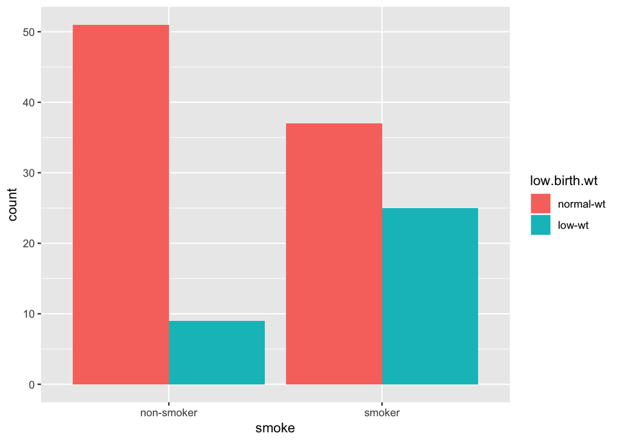

   ```r
   ggplot(birthwt.clean, aes(x=smoke, fill=low.birth.wt)) +
       geom_bar(position="dodge")
   ```

   ```r
   summary(glm(low.birth.wt~age, data=birthwt.clean, family="binomial"))
   ```

   ```
   ##
   ## Call:
   ## glm(formula = low.birth.wt ~ age, family = "binomial", data = birthwt.clean)
   ##
   ## Deviance Residuals:
   ##     Min       1Q   Median       3Q      Max
   ## -0.9527  -0.8438  -0.7642   1.4768   1.7991
   ##
   ## Coefficients:
   ##             Estimate Std. Error z value Pr(>|z|)
   ## (Intercept)  0.03562    0.90245   0.039    0.969
   ## age         -0.04215    0.03805  -1.108    0.268
   ##
   ## (Dispersion parameter for binomial family taken to be 1)
   ##
   ##     Null deviance: 144.38  on 121  degrees of freedom
   ## Residual deviance: 143.10  on 120  degrees of freedom
   ## AIC: 147.1
   ##
   ## Number of Fisher Scoring iterations: 4
   ```

   ```r
   chisq.test(table(birthwt.clean$low.birth.wt, birthwt.clean$smoke))
   ```

   ```
   ##
   ##  Pearson's Chi-squared test with Yates' continuity correction
   ##
   ## data:  table(birthwt.clean$low.birth.wt, birthwt.clean$smoke)
   ## X-squared = 8.5076, df = 1, p-value = 0.003537
   ```

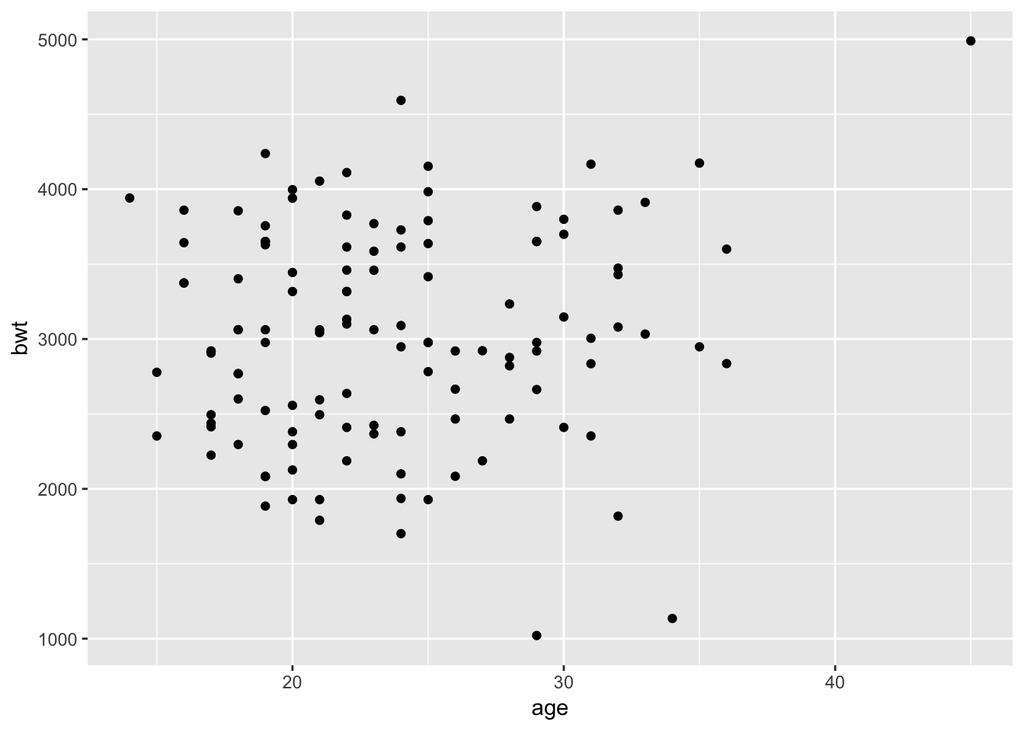

   ```r
   #For continuous outcome bwt
   ggplot(birthwt.clean, aes(x=age, y=bwt)) +
       geom_point()
   ```

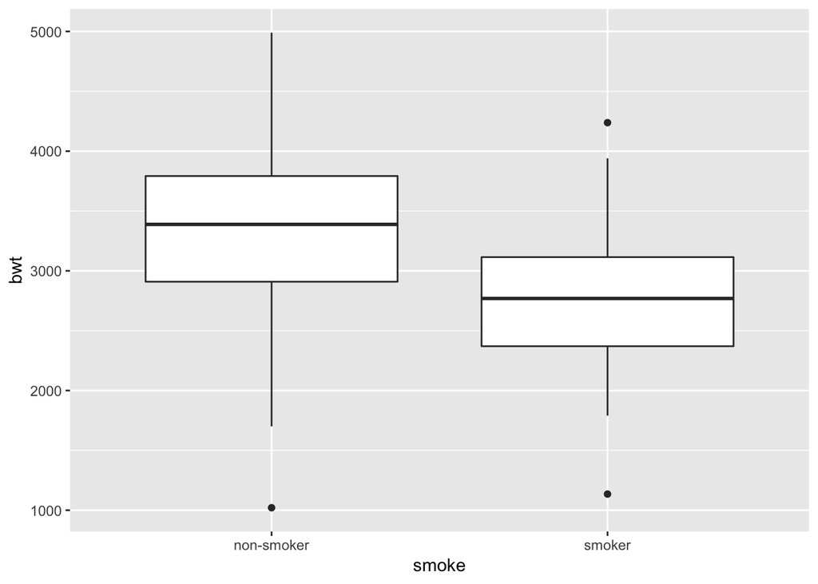

   ```r
   ggplot(birthwt.clean, aes(x=smoke, y=bwt)) +
       geom_boxplot()
   ```

   ```r
   summary(lm(bwt~age, data=birthwt.clean))
   ```

   ```
   ##
   ## Call:
   ## lm(formula = bwt ~ age, data = birthwt.clean)
   ##
   ## Residuals:
   ##      Min       1Q   Median       3Q      Max
   ## -2082.22  -498.35    -4.09   579.16  1638.62
   ##
   ## Coefficients:
   ##             Estimate Std. Error t value Pr(>|t|)
   ## (Intercept)  2653.42     283.75   9.351 6.04e-16 ***
   ## age            15.51      11.65   1.332    0.186
   ## ---
   ## Signif. codes:  0 '***' 0.001 '**' 0.01 '*' 0.05 '.' 0.1 ' ' 1
   ##
   ## Residual standard error: 722.3 on 120 degrees of freedom
   ## Multiple R-squared:  0.01456,    Adjusted R-squared:  0.006349
   ## F-statistic: 1.773 on 1 and 120 DF,  p-value: 0.1855
   ```

   ```r
   summary(lm(bwt~smoke, data=birthwt.clean))
   ```

   ```
   ##
   ## Call:
   ## lm(formula = bwt ~ smoke, data = birthwt.clean)
   ##
   ## Residuals:
   ##      Min       1Q   Median       3Q      Max
   ## -2254.62  -397.41    41.38   483.88  1714.38
   ##
   ## Coefficients:
   ##             Estimate Std. Error t value Pr(>|t|)
   ## (Intercept)   3275.6       88.1  37.181  < 2e-16 ***
   ## smokesmoker   -500.8      123.6  -4.053 9.03e-05 ***
   ## ---
   ## Signif. codes:  0 '***' 0.001 '**' 0.01 '*' 0.05 '.' 0.1 ' ' 1
   ##
   ## Residual standard error: 682.4 on 120 degrees of freedom
   ## Multiple R-squared:  0.1204, Adjusted R-squared:  0.1131
   ## F-statistic: 16.42 on 1 and 120 DF,  p-value: 9.028e-05
   ```

   ```r
   #For categorical outcome
   low.glm <- glm(low.birth.wt ~ age + race + smoke + hypertension + prem.labor, data=birthwt.clean, family="binomial")
   summary(low.glm)
   ```

   ```
   ##
   ## Call:
   ## glm(formula = low.birth.wt ~ age + race + smoke + hypertension +
   ##     prem.labor, family = "binomial", data = birthwt.clean)
   ##
   ## Deviance Residuals:
   ##     Min       1Q   Median       3Q      Max
   ## -1.6272  -0.8052  -0.4323   0.9780   2.2986
   ##
   ## Coefficients:
   ##                         Estimate Std. Error z value Pr(>|z|)
   ## (Intercept)             -1.47793    1.13864  -1.298  0.19429
   ## age                     -0.03759    0.04517  -0.832  0.40535
   ## raceblack                1.09873    0.53415   2.057  0.03969 *
   ## smokesmoker              1.35155    0.50231   2.691  0.00713 **
   ## hypertensionHTN          1.04344    0.77843   1.340  0.18010
   ## prem.laborprem-labor-hx  1.35777    0.58036   2.340  0.01931 *
   ## ---
   ## Signif. codes:  0 '***' 0.001 '**' 0.01 '*' 0.05 '.' 0.1 ' ' 1
   ##
   ## (Dispersion parameter for binomial family taken to be 1)
   ##
   ##     Null deviance: 144.38  on 121  degrees of freedom
   ## Residual deviance: 121.98  on 116  degrees of freedom
   ## AIC: 133.98
   ##
   ## Number of Fisher Scoring iterations: 4
   ```

   ```r
   #For continuous outcome
   bwt.lm <- lm(bwt ~ age + race + smoke + hypertension + prem.labor, data=birthwt.clean)
   summary(bwt.lm)
   ```

   ```
   ##
   ## Call:
   ## lm(formula = bwt ~ age + race + smoke + hypertension + prem.labor,
   ##     data = birthwt.clean)
   ##
   ## Residuals:
   ##      Min       1Q   Median       3Q      Max
   ## -2416.01  -370.74     9.87   449.21  1477.05
   ##
   ## Coefficients:
   ##                         Estimate Std. Error t value Pr(>|t|)
   ## (Intercept)             3299.358    294.696  11.196  < 2e-16 ***
   ## age                        4.746     11.123   0.427 0.670375
   ## raceblack               -436.628    152.273  -2.867 0.004917 **
   ## smokesmoker             -498.975    126.584  -3.942 0.000139 ***
   ## hypertensionHTN         -155.622    245.796  -0.633 0.527893
   ## prem.laborprem-labor-hx -230.093    176.534  -1.303 0.195022
   ## ---
   ## Signif. codes:  0 '***' 0.001 '**' 0.01 '*' 0.05 '.' 0.1 ' ' 1
   ##
   ## Residual standard error: 660.4 on 116 degrees of freedom
   ## Multiple R-squared:  0.2038, Adjusted R-squared:  0.1695
   ## F-statistic: 5.939 on 5 and 116 DF,  p-value: 6.316e-05
   ```

   Significant predictors of categorical outcome: race, smoking, previous premature labor. Significant predictors of continous outcome: race, smoking. Race and smoking are signifcant predictors for both outcomes even when adjusting for other variables, giving us more confidence that the associations are related to the low birth weight outcome. Previous premature labors are associated with the categorical, but not continuous, outcome. A larger sample size and/or further analyses would help us determine whether this variable is truly significant or not.